# State Investigation App

Remco Bekker

20-2-2019

## Table of Contents

1. Purpose of the State Investigation APP
2. Usage of the State Investigation APP
3. Link to the State Investigation APP

## Purpose of the State Investigation APP

The purpose of the State Investigation APP is twofold

1. Allowing any user to investigate the state data in the state.x77 dataset through a simple web interace
2. Showing an interactive Shiny web app that meets the requirements of the assignment

Here’s a sample of the state.x77 dataset:

```
##            Population Income Illiteracy Life Exp Murder HS Grad Frost
## Alabama          3615   3624        2.1    69.05   15.1    41.3    20
## Alaska            365   6315        1.5    69.31   11.3    66.7   152
## Arizona          2212   4530        1.8    70.55    7.8    58.1    15
## Arkansas         2110   3378        1.9    70.66   10.1    39.9    65
## California      21198   5114        1.1    71.71   10.3    62.6    20
## Colorado         2541   4884        0.7    72.06    6.8    63.9   166
##              Area
## Alabama     50708
## Alaska     566432
## Arizona    113417
## Arkansas    51945
## California 156361
## Colorado   103766
```

## Usage of the State Investigation APP

In the left panel of the APP you can select an x and y variable that will be used to create a scatterplot of the two variables selected. And you can enter an x value that will be used to calculate a prediction value.

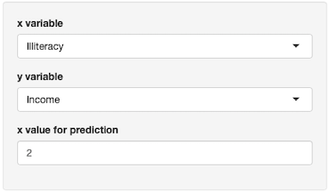

In the main panel on the right a scatterplot graph will be created based on the selected x and y variables. Furthermore a simple regression line is plotted in the graph as well as a blue horizontal and vertical line based on the entered x value for prediction and the predicted y value. Below the graph the prediction value of the entered x value is calculated (if possible)

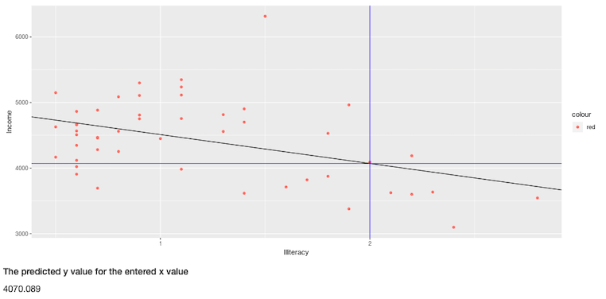

Bewow the graph a map of the US is shown with its various states. If you hover over a state a text will be shown with the values of the selected x and y variables for that specific state.

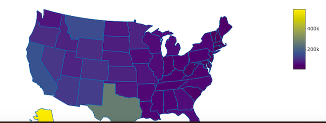

## Link to the APP

The APP can be reached by clicking on this link [State Investigation APP](https://remcoebekker.shinyapps.io/stateinvestigationapp/)